# Reproducible Research: Peer Assessment 1

Pinecode99 (Mark)

October 23, 2016

# Loading and preprocessing the data

Assuming you have manually downloaded the data, you can load it with the following R code:

```r
library(dplyr)
library(lubridate)
act1 <- read.csv("./activity.csv", header = TRUE, sep = ",")
```

# What is mean total number of steps taken per day?

Part 1 answer  
Total steps per day:

```r
act2 <- aggregate(steps~date,act1,sum)
act2
```

```
##          date steps
## 1  2012-10-02   126
## 2  2012-10-03 11352
## 3  2012-10-04 12116
## 4  2012-10-05 13294
## 5  2012-10-06 15420
## 6  2012-10-07 11015
## 7  2012-10-09 12811
## 8  2012-10-10  9900
## 9  2012-10-11 10304
## 10 2012-10-12 17382
## 11 2012-10-13 12426
## 12 2012-10-14 15098
## 13 2012-10-15 10139
## 14 2012-10-16 15084
```

[output cut: 39 more lines]

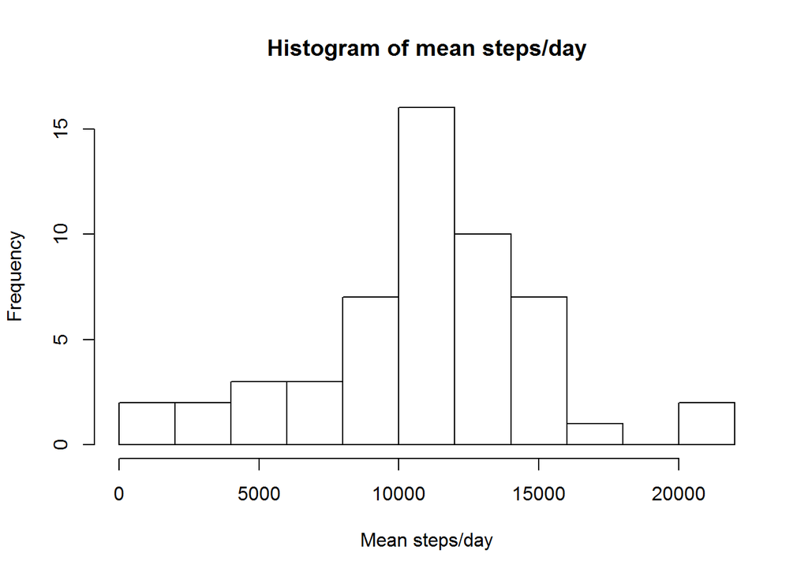

```r
hist(act2$steps,breaks=15, main="Histogram of mean steps/day", xlab="Mean steps/day")
```

Part 3 answer Mean and median of the total number of steps per day

```r
act3 <- as.data.frame(mean(act2$steps))
names(act3) <- "mean"
act4 <- as.data.frame(median(act2$steps))
names(act4) <- "median"
act5 <- cbind(act3, act4)
act5
```

```
##       mean median
## 1 10766.19  10765
```

```r
# rm(act2,act3,act4)
```

# What is the average daily activity pattern?

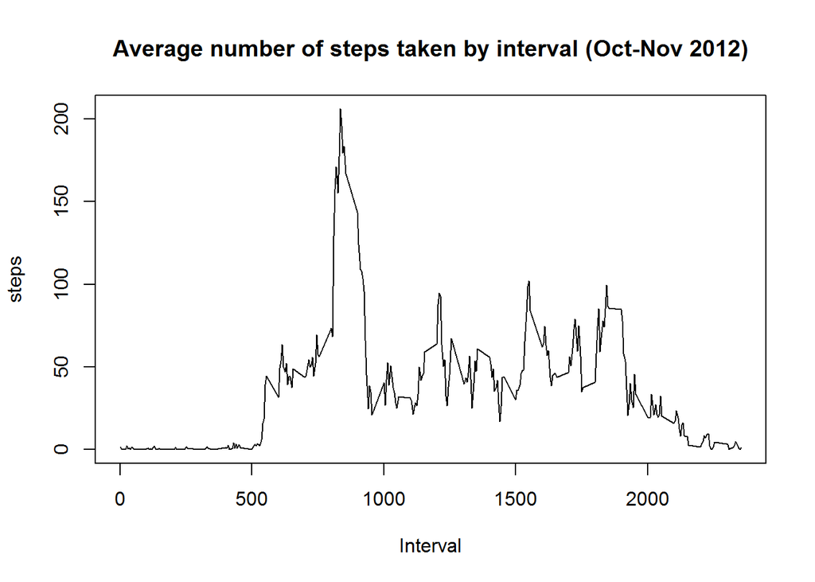

```r
act10 <- aggregate(steps~interval,act1,mean)
plot(steps~interval,data=act10, type="l", xlab="Interval", main="Average number of steps taken by interval (Oct-Nov 2012)")
```

Which 5-minute interval, on average across all the days in the dataset,  
contains the maximum number of steps?

```r
MaxInt1 <- which.max(act10$steps)
MaxInt2 <- act10[MaxInt1,]
MaxInt2
```

```
##     interval    steps
## 104      835 206.1698
```

# Imputing missing values

Calculate and report the total number of missing values in the dataset  
(i.e. the total number of rows with NA’s)

```r
sum(is.na(act1[,1]))
```

```
## [1] 2304
```

Devise a strategy for filling in all of the missing values in the dataset.  
My strategy will be to use the mean of the relevant segments.

Create a new dataset that is equal to the original dataset but with the missing  
data filled in. create a new copy from act1 to work with.

```r
act30 <- act1
#rm(act1)

for (i in 1:nrow(act30))
{
       if (is.na(act30$steps[i]))
       {
         #build code to lookup mean data based on the interval
         interval1 <- act30[i,3]
         interval2 <- which(act10$interval==interval1)
         meansteps <- act10[interval2,2]
         act30[i,1] <- meansteps
       }

}

#rm(act10)
# sum(is.na(act30[,1])) # demosstrates the NA's have been replaced
```

Make a histogram of the total number of steps taken each day and Calculate and report the  
mean and median total number of steps taken per day. Do these values differ from the estimates  
from the first part of the assignment? What is the impact of imputing missing data on the estimates  
of the total daily number of steps?

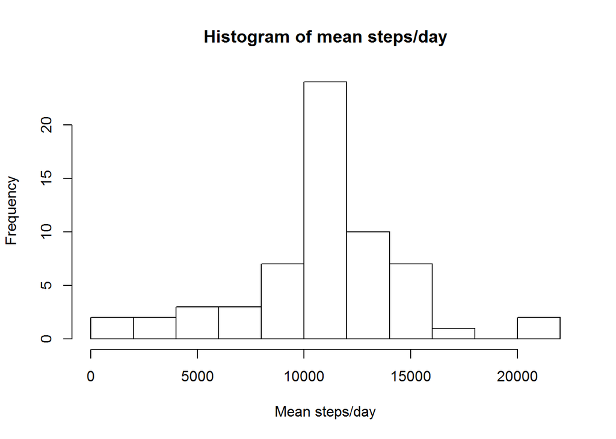

```r
act31 <- aggregate(steps~date,act30,sum)
hist(act31$steps,breaks=15, main="Histogram of mean steps/day", xlab="Mean steps/day")
```

create a file for mean and one for median and combine them

```r
act32 <- as.data.frame(mean(act31$steps))
names(act32) <- "mean"
act33 <- as.data.frame(median(act31$steps))
names(act33) <- "median"
act34 <- cbind(act32, act33)
```

this is the result (coincidentally! (or not) the mean and median are forced to be  
the same using the method choosen) this can be demonstrated by sorting the act31 column by steps

```r
act34
```

```
##       mean   median
## 1 10766.19 10766.19
```

```r
#rm(act31,act32,act33,act34)
```

answer: the results differ by a small amout. Using averaged data for the missing data ‘tightened up’ the histogram  
making the data more centrally located than would have been the case if we had the real data.

# Are there differences in activity patterns between weekdays and weekends?

For this part the weekdays() function may be of some help here. Use the dataset with the  
filled in missing values for this part

Create a new factor variable in the dataset with two levels weekday and weekend  
indicating whether a given date is a weekday or weekend day.

```r
act40 <- act30
rm(act30)
act40$date <- as.Date(act40$date)
act41 <- mutate(act40, daycode = weekdays(date))
act42 <- mutate(act41,code="a")

for (i in 1:nrow(act42))
{
        if (act42$daycode[i] == "Saturday" | act42$daycode[i] == "Sunday")
        {
               act42$code[i] <- "weekend"
        }
        else
        {
                act42$code[i] <- "weekday"
        }

}
#head(act42,5)
#rm(act41)
```

This plot shows the differences in step activity on average  
between weekdays and weekends.

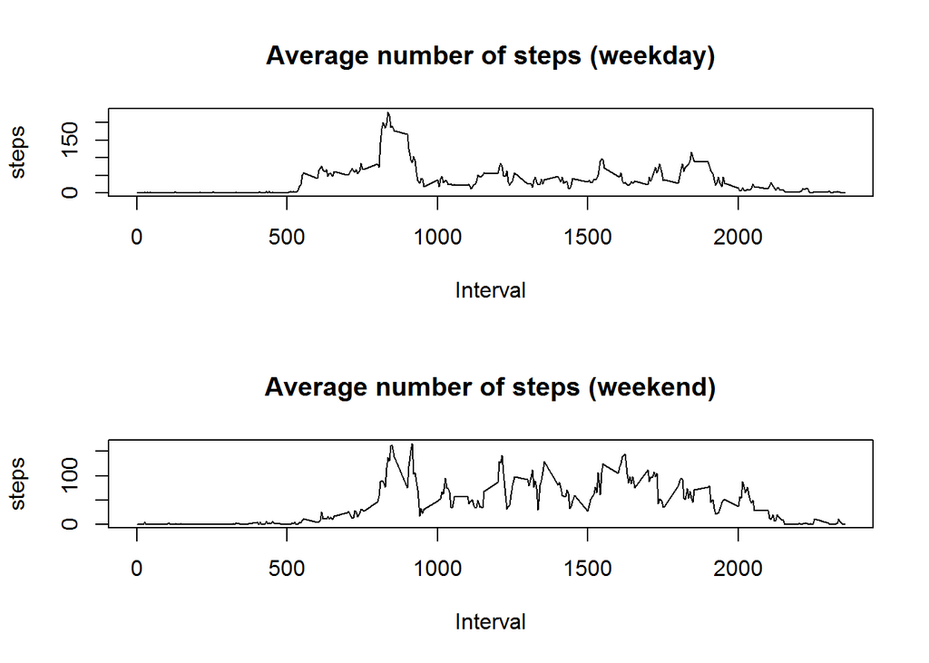

```r
par(mfrow=c(2,1))

### a plot for weekdays
act50 <- filter(act42,code=="weekday")
act51 <- aggregate(steps~interval,act50,mean)
plot(steps~interval,data=act51, type="l", xlab="Interval", main="Average number of steps (weekday)")

### a plot for weekends
act55 <- filter(act42,code=="weekend")
act56 <- aggregate(steps~interval,act55,mean)
plot(steps~interval,data=act56, type="l", xlab="Interval", main="Average number of steps (weekend)")
```

```r
###dev.off()

#rm(act40,act42,act50,act51,act55,act56)
```